# Karen’s Week 5 Work

## Instructions

The following exercises are a test in disguise. What do you think about the coding? Can you think of any improvements to the following?

## Preparations

### Installing packages

```r
library(tidyverse)
```

```r
library(ggplot2)
```

### Loading datasets

```r
aq = readRDS("anscombe_quartet.rds")
dd = readRDS("datasaurus_dozen.rds")
```

## PROBLEM 1

Visualizing your data is important! Summary statistics can be highly misleading, and simply plotting the data can reveal a lot more! Lets look at the Anscombe’s Quartet data. There are four different data sets.

*Anscombe, F. J. (1973). “Graphs in Statistical Analysis”. American Statistician. 27 (1): 17–21. doi:10.1080/00031305.1973.10478966. JSTOR 2682899.*

### Data exploration

```r
str(aq)
```

```
## tibble [44 × 3] (S3: tbl_df/tbl/data.frame)
##  $ dataset: chr [1:44] "dataset_1" "dataset_1" "dataset_1" "dataset_1" ...
##  $ x      : num [1:44] 10 8 13 9 11 14 6 4 12 7 ...
##  $ y      : num [1:44] 8.04 6.95 7.58 8.81 8.33 ...
```

*Q: What does the function str() do?*

A: It displays the internal structure of the dataset.

```r
aq %>% group_by(dataset) %>%
  summarise( mean_x =mean(x),
             mean_y = mean(y),
             min_x = min(x),
             min_y = min(y),
             max_x = max(x),
             max_y = max(y),
             crrltn = cor(x, y) )
```

```
## # A tibble: 4 × 8
##   dataset   mean_x mean_y min_x min_y max_x max_y crrltn
##   <chr>      <dbl>  <dbl> <dbl> <dbl> <dbl> <dbl>  <dbl>
## 1 dataset_1      9   7.50     4  4.26    14 10.8   0.816
## 2 dataset_2      9   7.50     4  3.1     14  9.26  0.816
## 3 dataset_3      9   7.5      4  5.39    14 12.7   0.816
## 4 dataset_4      9   7.50     8  5.25    19 12.5   0.817
```

*Q: what do the summary statistics tell us about the different datasets?*

### Data visualisation

```r
plot1 <- ggplot(aq, aes(x=x,y=y)) +
  geom_point() +
  geom_smooth(method = "lm",formula = "y ~ x") + facet_wrap(~dataset)

ggsave("plot1.png", width = 20, height = 20, units = "cm")
```

[output not shown]

*Q: what do the plots tell us about the different datasets?*

A: it visualises the relationship between x and y values in each dataset

*Q: describe the relationship between x and y in the different datasets.*

A: 1. fairly linear 2. quadratic 3. very linear with what looks like an outlier 4. all data points except 1 have the same x value and different y values

*Q: would linear regression be an appropriate statistical model to analyse the x-y relationship in each dataset?*

A: It is suitable for 3 and potentially for 1, but not for 2 and 4

*Q: what conclusions can you draw for the plots and summary statistics?*

A: summary statistics don’t accurately capture characteristics of the dataset, so visualisation is very important.

## PROBLEM 2

### Data exploration

```r
summary(dd)
```

```
##    dataset                x               y
##  Length:1846        Min.   :15.56   Min.   : 0.01512
##  Class :character   1st Qu.:41.07   1st Qu.:22.56107
##  Mode  :character   Median :52.59   Median :47.59445
##                     Mean   :54.27   Mean   :47.83510
##                     3rd Qu.:67.28   3rd Qu.:71.81078
##                     Max.   :98.29   Max.   :99.69468
```

*Q: how many rows and columns does the datasaurus_dozen file have?*

### Data visualisation

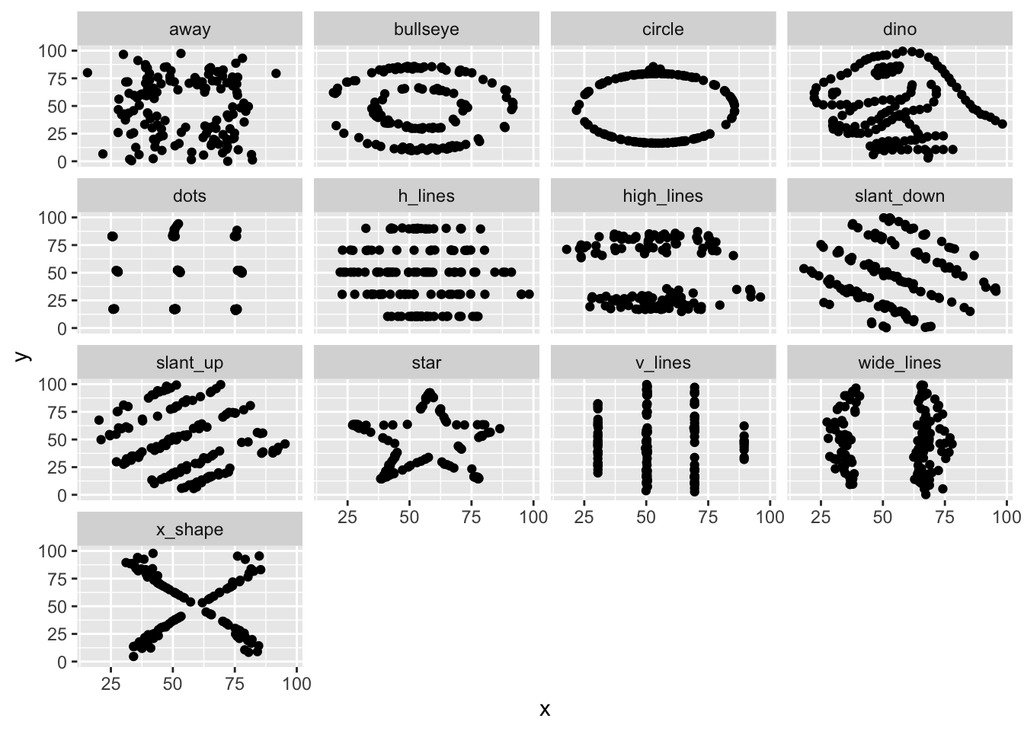

```r
ggplot(dd, aes(x=x,y=y)) + geom_point() + facet_wrap(~dataset)
```

*Q: calculate the correlations and summary statistics for x and y in all datasets:*

```r
# A:
dd %>%
  group_by(dataset) %>%
  summarise( mean_x = mean(x),
             mean_y = mean(y),
             min_x = min(x),
             min_y = min(y),
             max_x = max(x),
             max_y = max(y),
             crrltn = cor(x, y) )
```

```
## # A tibble: 13 × 8
##    dataset    mean_x mean_y min_x   min_y max_x max_y  crrltn
##    <chr>       <dbl>  <dbl> <dbl>   <dbl> <dbl> <dbl>   <dbl>
##  1 away         54.3   47.8  15.6  0.0151  91.6  97.5 -0.0641
##  2 bullseye     54.3   47.8  19.3  9.69    91.7  85.9 -0.0686
##  3 circle       54.3   47.8  21.9 16.3     85.7  85.6 -0.0683
##  4 dino         54.3   47.8  22.3  2.95    98.2  99.5 -0.0645
##  5 dots         54.3   47.8  25.4 15.8     78.0  94.2 -0.0603
##  6 h_lines      54.3   47.8  22.0 10.5     98.3  90.5 -0.0617
##  7 high_lines   54.3   47.8  17.9 14.9     96.1  87.2 -0.0685
##  8 slant_down   54.3   47.8  18.1  0.304   95.6  99.6 -0.0690
##  9 slant_up     54.3   47.8  20.2  5.65    95.3  99.6 -0.0686
## 10 star         54.3   47.8  27.0 14.4     86.4  92.2 -0.0630
## 11 v_lines      54.3   47.8  30.4  2.73    89.5  99.7 -0.0694
## 12 wide_lines   54.3   47.8  27.4  0.217   77.9  99.3 -0.0666
## 13 x_shape      54.3   47.8  31.1  4.58    85.4  97.8 -0.0656
```

*Q: Plot the relationships between x and y in each dataset including the line of best fit.*

```r
# A:
plot2 <- ggplot(dd, aes(x=x,y=y)) + geom_point() + geom_smooth(method = "lm",formula = "y ~ x") + facet_wrap(~dataset)
ggsave("plot2.png")
```

[output not shown]

*Q: what conclusions can you draw for the plots and summary statistics?*